# Ranking Underlyings with GARCH

Pritam Dalal

3/15/2019

In this analysis, we calculate GARCH forecasts for each underlying/expiration combination. We then calculate a forecasted volatility premium for each underlying, and rank the underlyings using this forecast. We then compare the performance of different groupings: halves, thirds, fourths, sixths, and twelfths.

### Halves

The simplest grouping of underlyings per expiration is to consider the top-half and bottom-half.

As we can see from the following bar graph, there is significantly better performance in the top group as compared to the bottom group, particularly when delta-hedging.

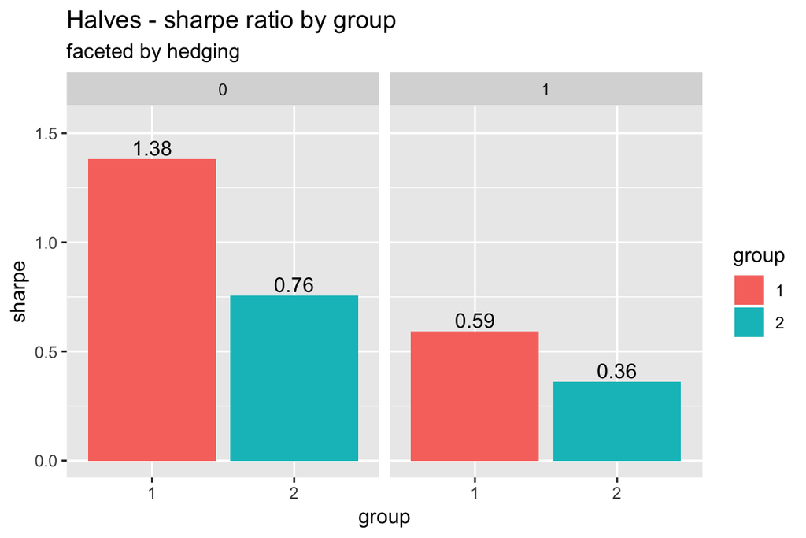

The following bar graph show how many times each underlying was in the top group, this seems pretty strongly correlated with the overall performance of the underlying over the five year period.

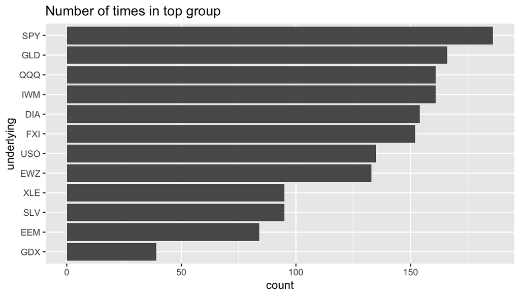

The following two graphs show that for all loss-trigger levels, the top-half outperforms the bottom half. It also seems that loss-trigger risk-management is more effective for the top half, but it’s hard to know if this is just a random artifact of the data.

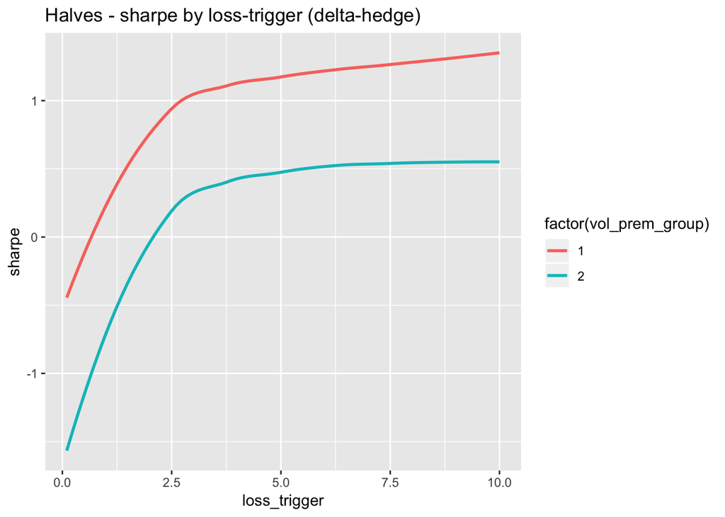

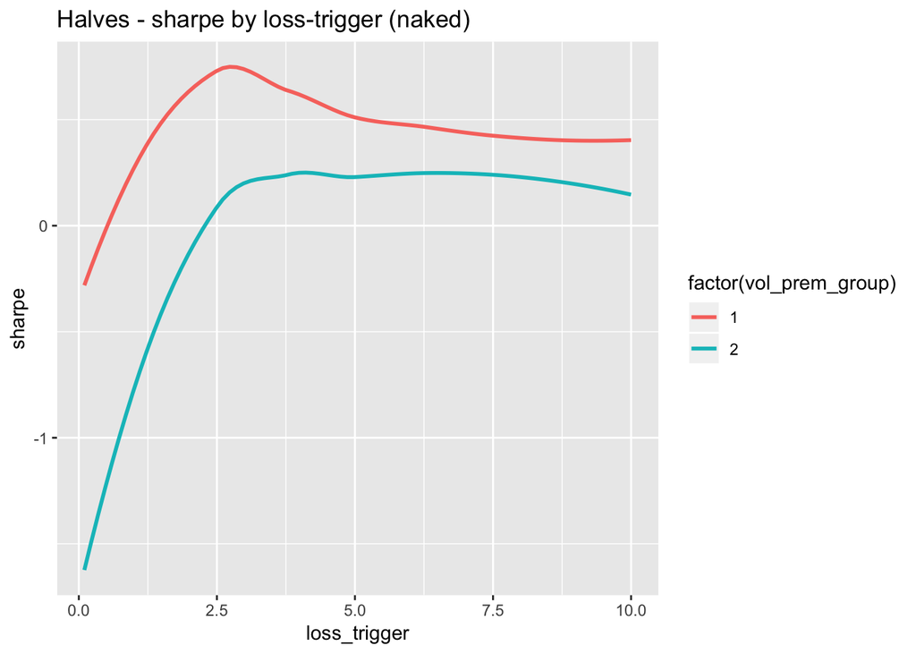

It is interesting to check if the out-performance of the top group occurs for each year. This seems to be mostly the case, but it’s not 100% true. In the case of delta-hedging, for 2017 and 2018, the bottom group performed better. In the case of naked options, the bottom group performed better in 2018.

The fact that the top group didn’t outperform in all years is a bit dissatisfying. However, there is probably not enough data to make these results too concerning. Also, there were some underlyings that were hit much harder in 2018, and those may have had higher forecasted vol premium, just by chance.

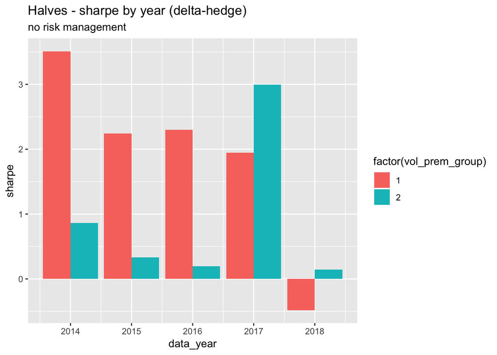

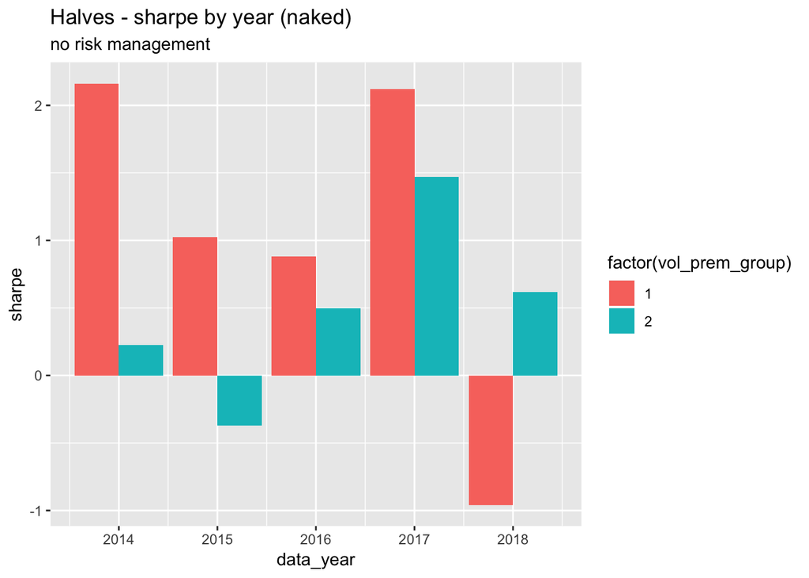

### Thirds

When breaking the underlyings into three groups, we mostly see the expected ordering of performance. However, in the case of naked option selling the middle does worse than the bottom group.

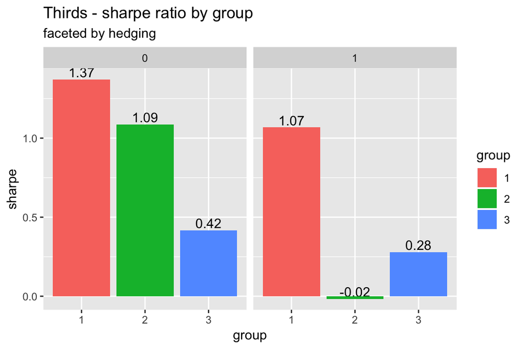

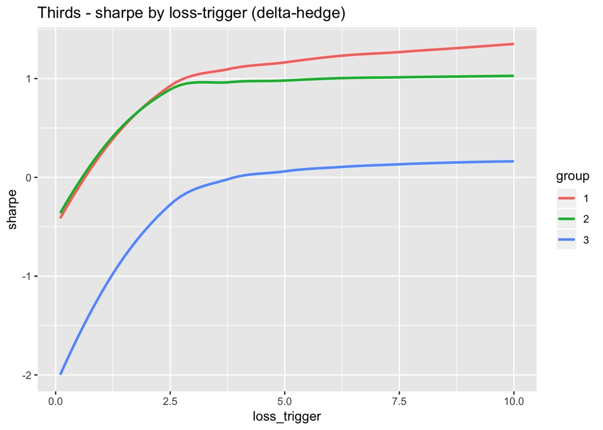

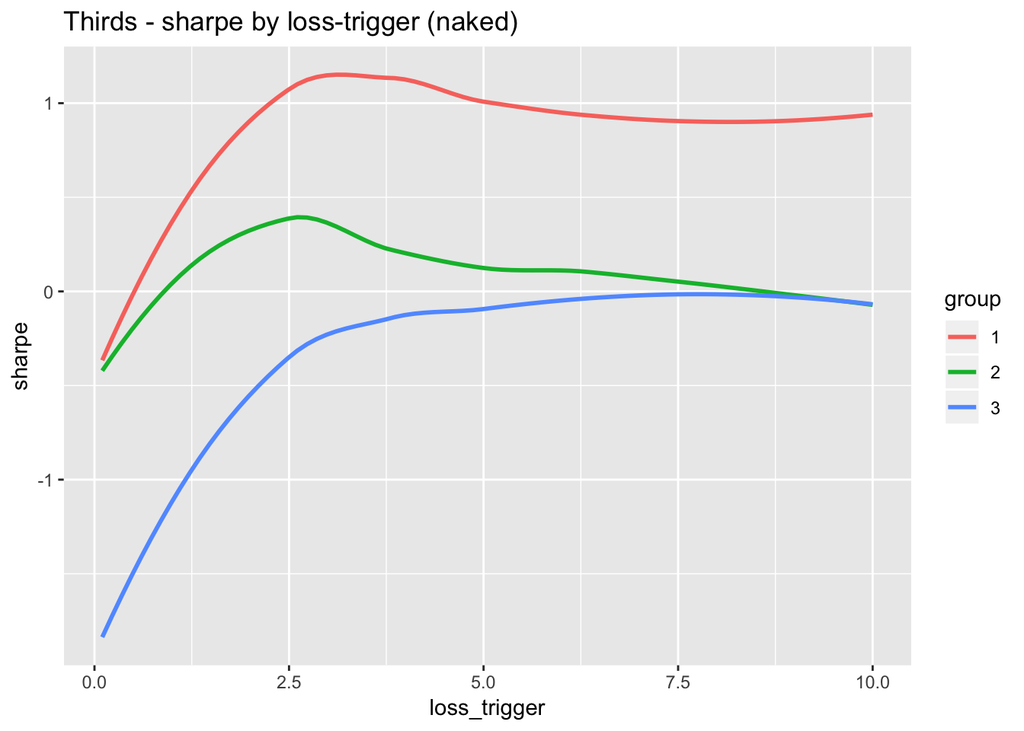

### More Granular

I also consider groups of fourths, sixths, and twelfths (singleton). The results get quite a bit noisier, but they are in general directionally correct, so overall I am satisfied that the GARCH-based volatility premium forecast is predictive.

#### Fourths

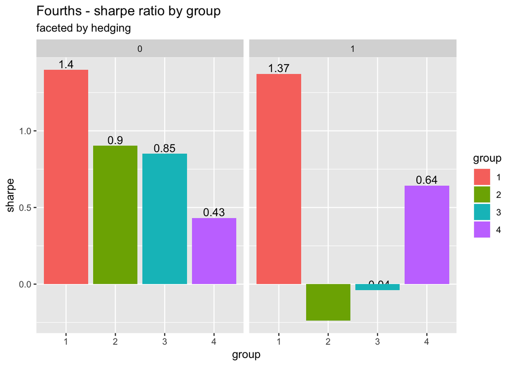

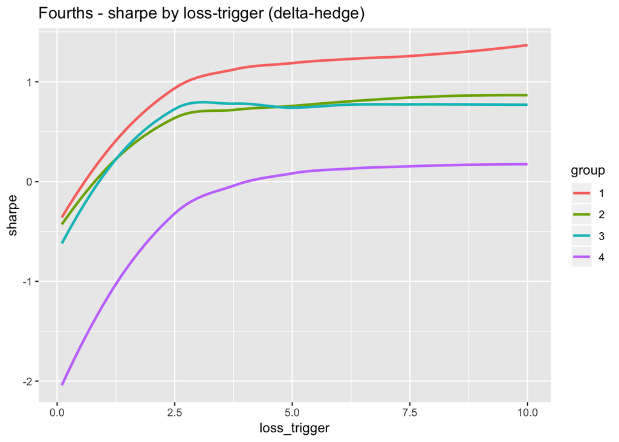

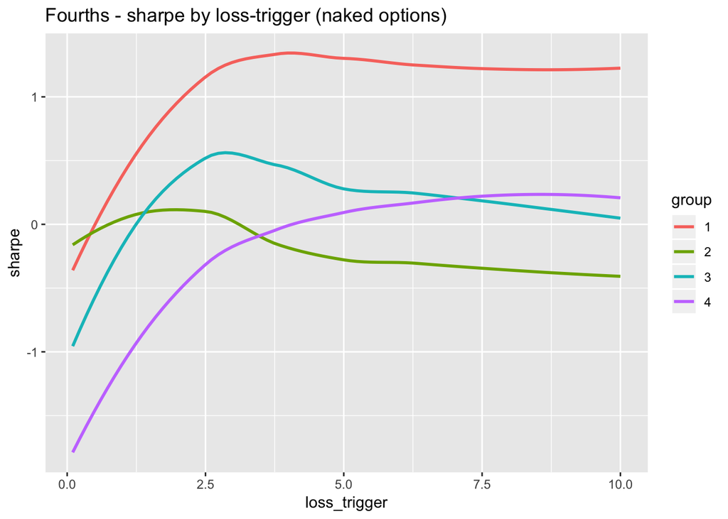

#### Sixths

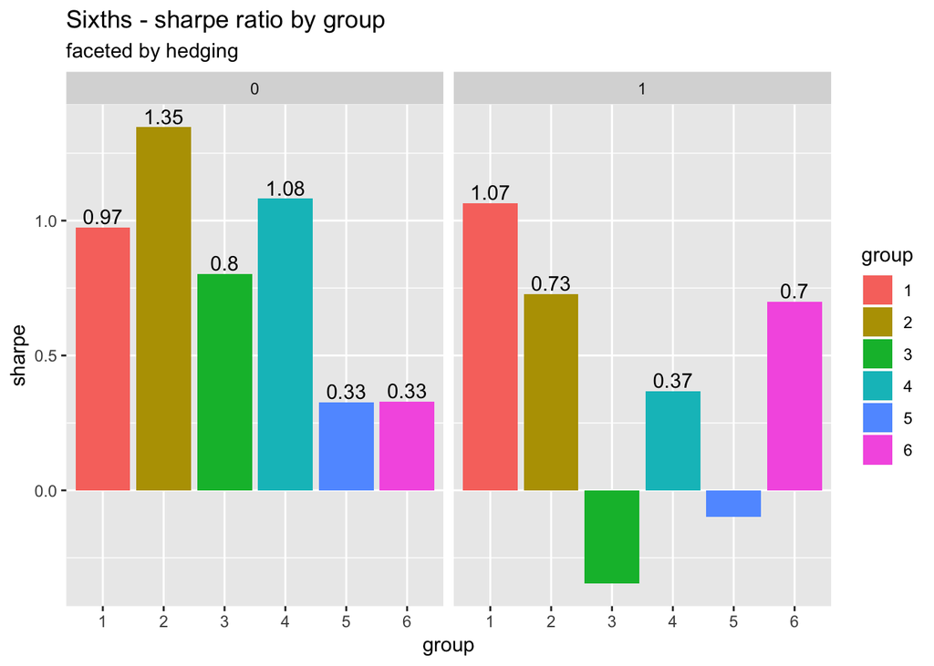

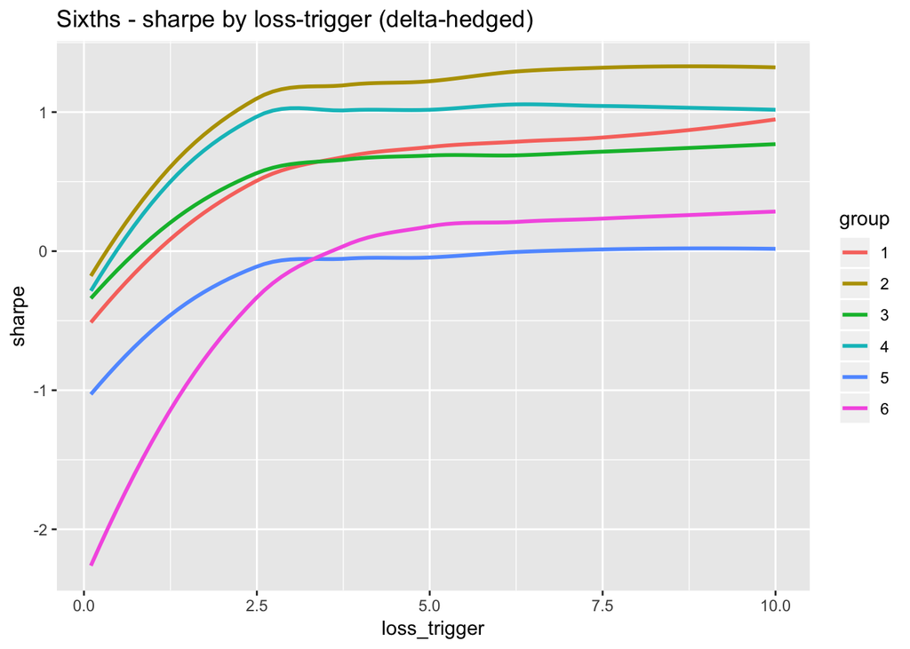

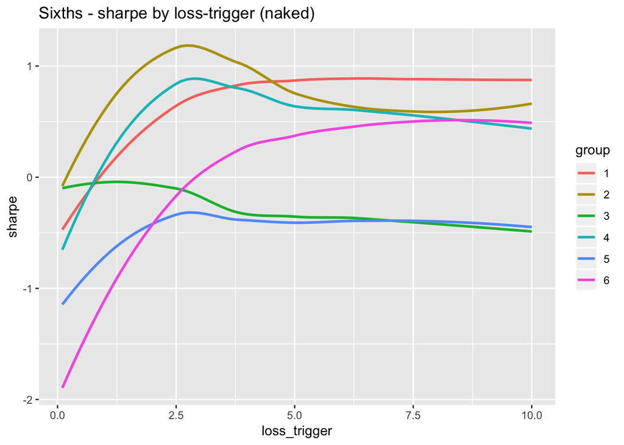

#### Twelfths

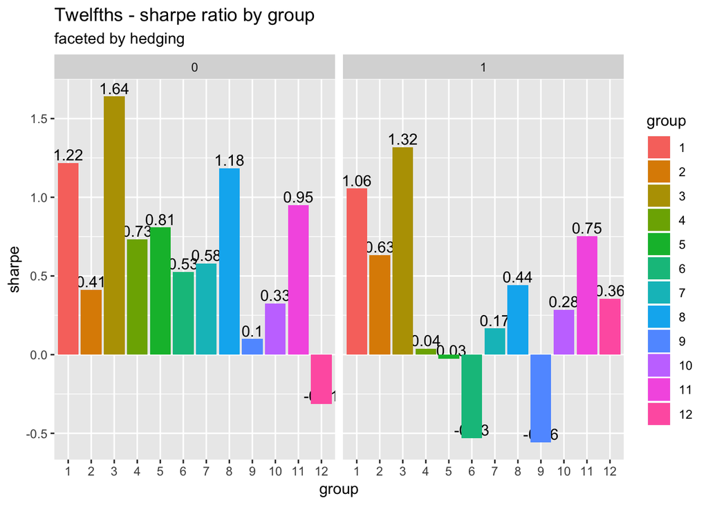

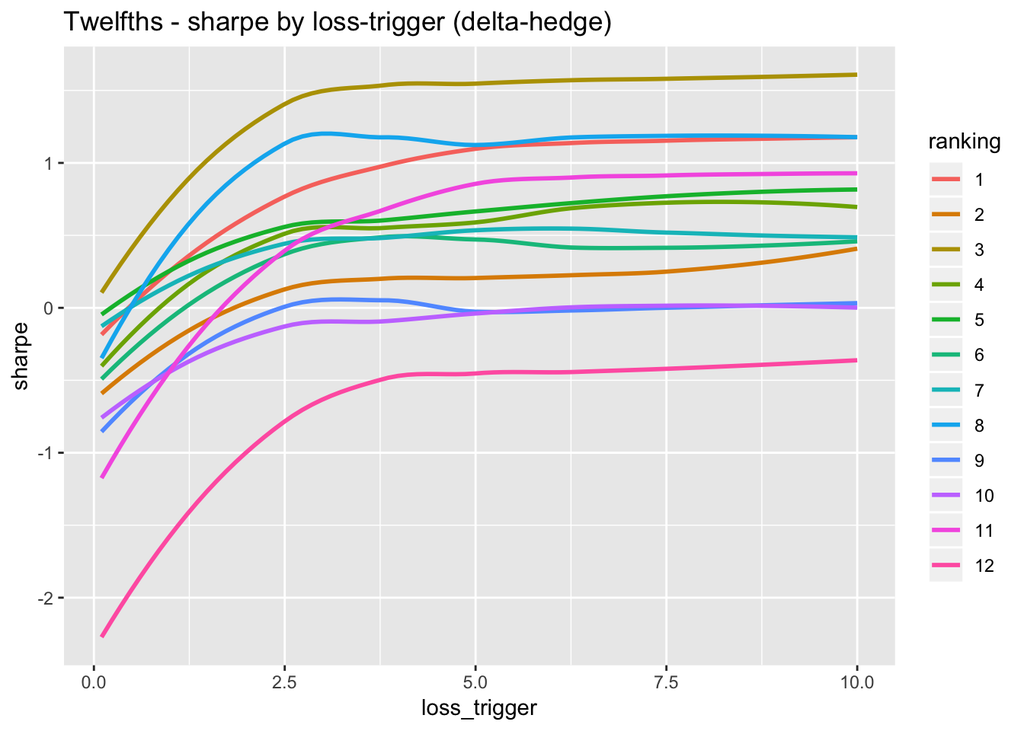

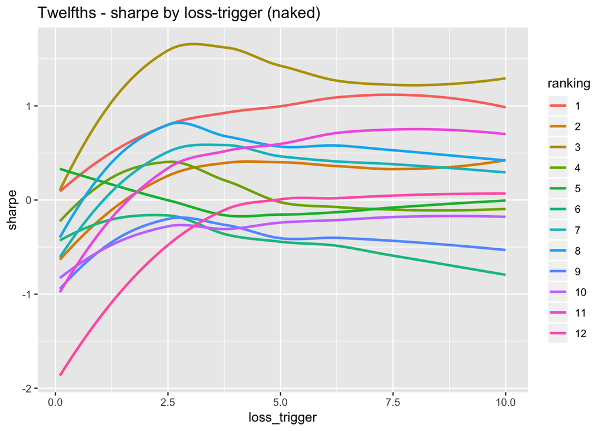

### Conclusions

These results demonstrate that GARCH based volatility estimates do provide information about future estimates about volatility. I have been trading for a couple of months using these estimates to pick the underlyings, and I will continue to do so.

In another analysis it would be interesting to show that with monthly options, there is less information in the GARCH estimates.